# DV2 - Homework 1.

Son Nam Nguyen

16 January 2022

## 0. Load the nycflights13 package and check what kind of datasets exist in the package, then create a copy of flights dataset into a data.table object, called flight_data.

```r
flight_data <- setDT(nycflights13::flights)

datasets <- as.data.frame(data(package='nycflights13')$results)[c('Item', 'Title')]

kable(datasets)
```

| Item | Title |
| --- | --- |
| airlines | Airline names. |
| airports | Airport metadata |
| flights | Flights data |
| planes | Plane metadata. |
| weather | Hourly weather data |

## 1. Which destination had the lowest avg arrival delay from LGA with minimum 100 flight to that destination?

```r
flight_data[origin == 'LGA', .(
  mean_arr_delay = mean(arr_delay, na.rm = T),
  number_of_flights = .N),
  by =dest][number_of_flights >= 100][order(mean_arr_delay)][1]
```

```
##    dest mean_arr_delay number_of_flights
## 1:  DAY      -4.947368               391
```

## 2. Which destination’s flights were the most on time (avg arrival delay closest to zero) from LGA with minimum 100 flight to that destination?

```r
flight_data[origin == 'LGA', .(
  mean_arr_delay = abs(mean(arr_delay, na.rm = T)),
  number_of_flights = .N),
  by =dest][number_of_flights >= 100][order(mean_arr_delay)][1]
```

```
##    dest mean_arr_delay number_of_flights
## 1:  MIA      0.0657664              5781
```

## 3. Who is the manufacturer of the plane, which flights the most to CHS destination?

```r
planes <- setDT(nycflights13::planes)

merge(
  flight_data[dest == 'CHS', .(
    number_of_flights = .N),
    by = .(tailnum)][order(-number_of_flights)][1],
  planes[ , c('tailnum', 'manufacturer')])
```

```
##    tailnum number_of_flights   manufacturer
## 1:  N713EV                22 BOMBARDIER INC
```

## 4. Which airline (carrier) flow the most by distance?

```r
airlines <- setDT(nycflights13::airlines)

merge(
  flight_data[, .(
    sum_of_distance = sum(distance)),
    by = .(carrier)][order(-sum_of_distance)][1],
  airlines)
```

```
##    carrier sum_of_distance                  name
## 1:      UA        89705524 United Air Lines Inc.
```

## 5. Plot the monthly number of flights with 20+ mins arrival delay!

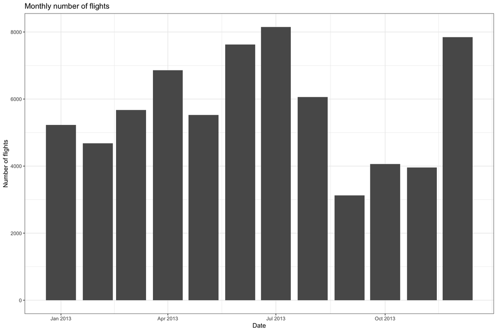

```r
monthly <- flight_data[arr_delay >= 20, .(number_of_flights = .N), by=(date = as.Date(format(time_hour, '%Y-%m-01')))]

ggplot(monthly, aes(date, number_of_flights)) +
  geom_col() +
  labs(title = 'Monthly number of flights',
       x = 'Date',
       y = 'Number of flights') +
  theme_bw()
```

## 6. Plot the departure delay of flights going to IAH and the related day’s wind speed on a scaterplot! Is there any association between the two variables? Try adding a linear model.

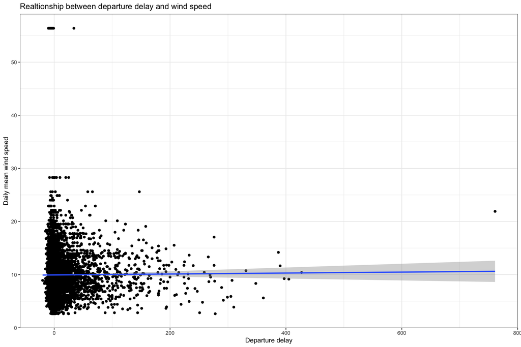

```r
weather <- setDT(nycflights13::weather)

weather <- weather[, .(mean_wind_speed = mean(wind_speed, na.rm = T)), by = .(year, month, day, origin)]

flight_data$date <- as.Date(flight_data$time_hour)

all <- merge(flight_data, weather, by = c('year', 'month', 'day', 'origin'))


ggplot(all[dest == 'IAH'], aes(dep_delay, mean_wind_speed)) +
  geom_point() +
  geom_smooth(method = 'lm') +
  labs(title = 'Realtionship between departure delay and wind speed',
       y = 'Daily mean wind speed',
       x = 'Departure delay') +
  theme_bw()
```

## 7. Plot the airports as per their geolocation on a world map, by mapping the number flights going to that destionation to the size of the symbol!

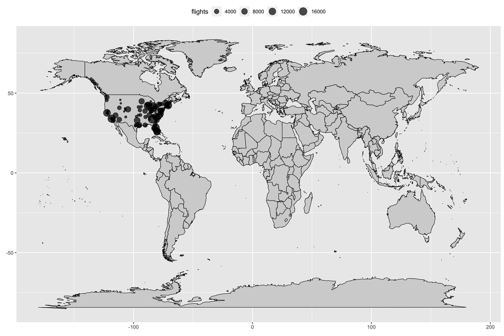

```r
flights <- flight_data[, .(flights = .N), by = 'dest']

geolocations <- merge(flights, airports, by.x = 'dest', by.y = 'faa')

world <- map_data("world")

ggplot() +
  geom_map(
    data = world, map = world,
    aes(long, lat, map_id = region),
    color = "black", fill = "lightgray", size = 0.3
  ) +
  geom_point(
    data = geolocations,
    aes(lon, lat, size = flights),
    alpha = 0.7
  ) +
  theme(legend.position = 'top') +
  labs(x = element_blank(),
       y = element_blank())
```